# Tachometer Refinement and Adjustment:

## Step 1: gather experimental data from on modified sensor

## Setup:

[figure not shown]

Once the button is presses, 10000 samples are recorded, as well as the time duration. A magnet is moved infront of the sensor randomly to generate voltage fluctuations. It is assumed that the readings are close enough to equidistal in time that they can be modeled as such.

```python
import struct
import numpy as np
import sympy as sym
import matplotlib.pyplot as plt

from scipy import signal
from mathtools import symbolic
```

```python
data = None
with open('no_filter_binary.txt', 'rb') as file:
    # read in the binary data
    data = file.read()
    # remove the stream primer
    data = data[1:]
    # calculated the time delta to ensure correctness
    start = struct.unpack('l', data[-8:-4])[0]
    end = struct.unpack('l', data[-4:])[0]
    total_time = end - start
    print(total_time)
```

```
1700004
```

```python
# extract the analog read values
vals = data[:-8]
vals = [struct.unpack('h', vals[i-2: i])[0] for i in range(2, len(vals), 2)]
```

```python
# create a time delta array
times = np.linspace(start, end, num=len(vals))
times = times - times[0]
times = list(times)
```

```python
# filter out bad values
points = [(v, t) for v, t in zip(vals, times) if (v > 0) and (v <= 1023)]
```

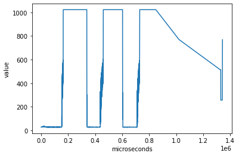

```python
# plot the data
x = [p[1] for p in points]
y = [p[0] for p in points]
plt.plot(x, y)
plt.xlabel("microseconds")
plt.ylabel("value");
```

```python
# chop off pad values
points = [(t,v) for t, v in zip(x, y) if (t < 0.8e6)]
```

```python
time = [p[0] for p in points]
vals = [p[1] for p in points]
```

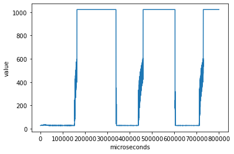

```python
plt.plot(time, vals);
plt.xlabel("microseconds")
plt.ylabel("value");
```

```
rise time = 10623.431485295296 us
```

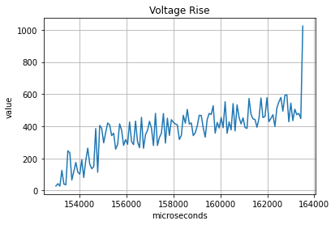

```python
s, e = 1800, 1925;
plt.plot(x[s:e], y[s:e]);
plt.grid()
plt.title("Voltage Rise")
plt.xlabel("microseconds")
plt.ylabel("value");
print('rise time =', (time[e] - time[s]), 'us');
```

Note that as the magnet approaches the hall effect sensor that the voltage increases in a stochastic manner. Once the voltage cross the 500 mark, the fluctuations go away and the voltage increases to 5V which corresponds to ~ 1000 reading This indicates that once the magnetic field strength reaches a critical value, the sensor reads HIGH and then shoots up.

```
fall time = 2209.6737489402294 us
```

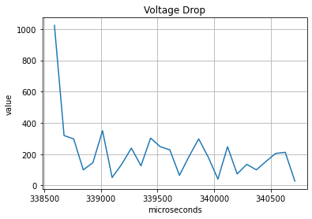

```python
s, e = 3984, 4010;
plt.plot(x[s:e], y[s:e]);
plt.grid()
plt.title("Voltage Drop")
plt.xlabel("microseconds")
plt.ylabel("value");
print('fall time =', (time[e] - time[s]), 'us');
```

We can observe behavior on the fall similar to that of the rise. The biggest difference is the time it takes to drop. As we can see from the plots of the three square waves, this behavior is consistent.

## Problem Identification

The cause of the spikes when using an arduino based tachometer with a hall effect sensor is a bouce between the HIGH and LOW threasholds for an arduino digital pin. The fall appears to be faster that the rise

## Proposed solution

# frequency analysis

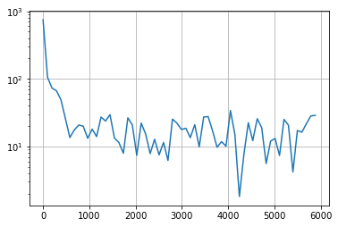

```python
from scipy.fft import fft
# setup sample data
s, e = 1800, 1925;
y1 = y[s:e]
x1 = x[s:e]

# Number of sample points
N = len(y1)

# sample spacing
T = (x1[1] - x1[0])/1e6;  # dT in seconds

x_data = np.linspace(0.0, N*T, N)
yf = fft(y1)
xf = np.linspace(0.0, 1.0/(2.0*T), N//2)
import matplotlib.pyplot as plt
plt.semilogy(xf, 2.0/N * np.abs(yf[0:N//2]))
plt.grid()
plt.show()
```

From the analysis it a appears that the desired cutoff frequency is around 1000 Hz, as there is noise beyond that

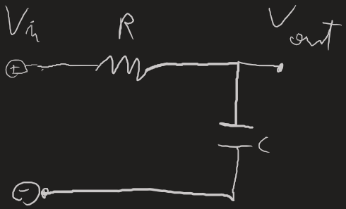

```python
# declare symbols
s, I, Vin, Vout, R, C = sym.symbols("s, I, Vin, Vout, R, C")
```

```python
Vin = I*(R + 1/(C*s))
Vout = Vin-(I*R)
tf = Vout/Vin
tf = tf.factor(s)
tf
```

$\displaystyle \frac{1}{C R s + 1}$

```python
# define cutoff frequency
f = 1000*2*sym.pi  # rad/s
Cap = 100e-9  # farads
eqn = f - 1/(R*C)
ans = sym.solve([eqn.subs(C, Cap)], [R])
ans[R]
```

$\displaystyle 1591.54943091895$

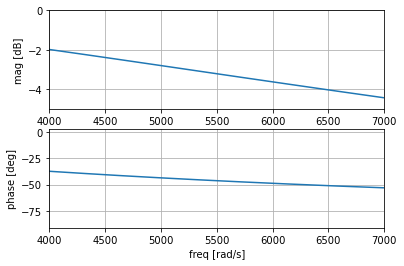

```python
%matplotlib inline
# create bode plot to verify
sys = signal.TransferFunction(
    *symbolic.sym2poly(
        # note the 1900 ohm resistor is what we actually have
        *sym.fraction(tf.subs({R: 1900, C: Cap})),
        floater=True
    )
)

freq, mag, phase = signal.bode(sys)
fig, (ax1, ax2) = plt.subplots(2, 1)
llim, hlim = 4e3, 7e3
# setup mag plot
ax1.plot(freq, mag)
ax1.set_xlabel("freq [rad/s]")
ax1.set_ylabel("mag [dB]")
ax1.set_xlim([llim, hlim])
ax1.set_ylim([-5, 0])
ax1.grid()
# setup phase plot
ax2.plot(freq, phase)
ax2.set_xlabel("freq [rad/s]")
ax2.set_ylabel("phase [deg]");
ax2.set_xlim([llim, hlim])
ax2.grid();
```

from the plots above, we can see that using the 1900 ohm resistor we actually have access to, shifts the cutoff frequency to 5500 rad/s which is around 900 hz. This should be fine based on the FFT analysis above. The frequency of 1000 hz was chosen to simplify the analysis. As long as the cutoff frequency stays above 500 we should be fine.

```python
# determine maximum allowable rise time
max_rpm = 3000
max_hz = max_rpm/60
max_time_delta = 1/max_hz
print(max_hz, max_time_delta)
```

[output not shown]

```python
# estimate range at which sensor can detect magnet
max_rise_time = max_time_delta*(50/360)
print(max_rise_time)
```

[output not shown]

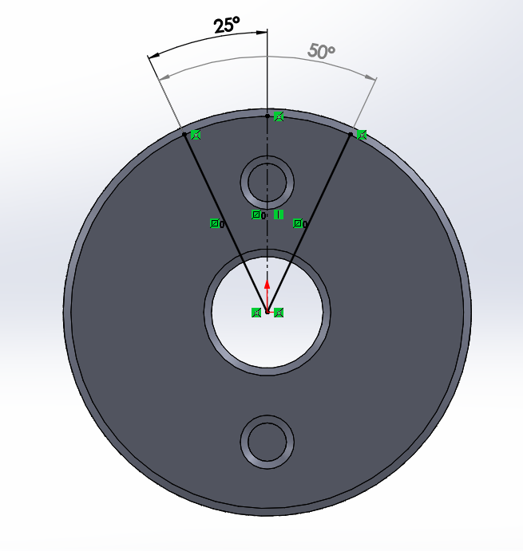

Note, that the rise time determined from the experimental setup is greater than the theoretical maximum rise time. The theoretical is 2.778 ms, while the experimental is 10 ms. This means that the rise time is a funciton of the magnet used, and the magnet that is actually used on the lathe currently is substansially stronger than the one used to collect data. Thus, the rise times collected from the experimental setup are most likely incorrect as the vibrations cause bouce that cuase the sensor currently in use to yeild extremely high RPM values speradically. It may be the case that the frequencies present in the signal are the same between the experimental setup and the actual setup. Thus an attempt will still be made to reduce the sensor noise and verify it's effectiveness.